```python
import pandas as pd
import numpy as np
import seaborn as sns
import matplotlib.pyplot as plt
import matplotlib
%matplotlib inline
matplotlib.rcParams['font.sans-serif'] = ['SimHei']
matplotlib.rcParams['axes.unicode_minus'] = False
```

```python
data = pd.read_csv("C:/Users/zhang/Desktop/facebook-ad-campaign/data.csv",encoding='gbk')
```

```python
data.head(20)
```

|  | 广告ID | 开始时间 | 停止时间 | 活动ID | FB跟踪活动ID | 对应年龄 | 性别 | 兴趣类别1 | 兴趣类别2 | 兴趣类别3 | 广告展示次数 | 广告点击次数 | 花费金额 | 看到广告后询问产品的人数 | 看到广告后购买产品的人数 |
| --- | --- | --- | --- | --- | --- | --- | --- | --- | --- | --- | --- | --- | --- | --- | --- |
| 0 | 708746 | 17/08/2017 | 17/08/2017 | 916 | 103916 | 30-34 | M | 15 | 17 | 17 | 7350.0 | 1 | 1.43 | 2.0 | 1.0 |
| 1 | 708749 | 17/08/2017 | 17/08/2017 | 916 | 103917 | 30-34 | M | 16 | 19 | 21 | 17861.0 | 2 | 1.82 | 2.0 | 0.0 |
| 2 | 708771 | 17/08/2017 | 17/08/2017 | 916 | 103920 | 30-34 | M | 20 | 25 | 22 | 693.0 | 0 | 0.00 | 1.0 | 0.0 |
| 3 | 708815 | 30/08/2017 | 30/08/2017 | 916 | 103928 | 30-34 | M | 28 | 32 | 32 | 4259.0 | 1 | 1.25 | 1.0 | 0.0 |
| 4 | 708818 | 17/08/2017 | 17/08/2017 | 916 | 103928 | 30-34 | M | 28 | 33 | 32 | 4133.0 | 1 | 1.29 | 1.0 | 1.0 |
| 5 | 708820 | 17/08/2017 | 17/08/2017 | 916 | 103929 | 30-34 | M | 29 | 30 | 30 | 1915.0 | 0 | 0.00 | 1.0 | 1.0 |
| 6 | 708889 | 17/08/2017 | 17/08/2017 | 916 | 103940 | 30-34 | M | 15 | 16 | 17 | 15615.0 | 3 | 4.77 | 1.0 | 0.0 |
| 7 | 708895 | 17/08/2017 | 17/08/2017 | 916 | 103941 | 30-34 | M | 16 | 20 | 18 | 10951.0 | 1 | 1.27 | 1.0 | 1.0 |
| 8 | 708953 | 17/08/2017 | 17/08/2017 | 916 | 103951 | 30-34 | M | 27 | 31 | 31 | 2355.0 | 1 | 1.50 | 1.0 | 0.0 |
| 9 | 708958 | 30/08/2017 | 30/08/2017 | 916 | 103952 | 30-34 | M | 28 | 32 | 31 | 9502.0 | 3 | 3.16 | 1.0 | 0.0 |
| 10 | 708979 | 30/08/2017 | 30/08/2017 | 916 | 103955 | 30-34 | M | 31 | 37 | 34 | 1224.0 | 0 | 0.00 | 1.0 | 0.0 |
| 11 | 709023 | 29/08/2017 | 29/08/2017 | 916 | 103962 | 30-34 | M | 7 | 8 | 8 | 735.0 | 0 | 0.00 | 1.0 | 0.0 |
| 12 | 709038 | 29/08/2017 | 29/08/2017 | 916 | 103965 | 30-34 | M | 16 | 20 | 22 | 5117.0 | 0 | 0.00 | 1.0 | 0.0 |
| 13 | 709040 | 29/08/2017 | 29/08/2017 | 916 | 103965 | 30-34 | M | 16 | 19 | 21 | 5120.0 | 0 | 0.00 | 1.0 | 0.0 |
| 14 | 709059 | 30/08/2017 | 30/08/2017 | 916 | 103968 | 30-34 | M | 20 | 26 | 23 | 14669.0 | 7 | 10.28 | 1.0 | 1.0 |
| 15 | 709105 | 30/08/2017 | 30/08/2017 | 916 | 103976 | 30-34 | M | 28 | 30 | 32 | 1241.0 | 0 | 0.00 | 1.0 | 1.0 |
| 16 | 709115 | 30/08/2017 | 30/08/2017 | 916 | 103978 | 30-34 | M | 30 | 34 | 31 | 2305.0 | 1 | 0.57 | 1.0 | 0.0 |
| 17 | 709124 | 30/08/2017 | 30/08/2017 | 916 | 103979 | 30-34 | M | 31 | 34 | 33 | 1024.0 | 0 | 0.00 | 1.0 | 1.0 |
| 18 | 709179 | 30/08/2017 | 30/08/2017 | 916 | 103988 | 35-39 | M | 15 | 16 | 17 | 4627.0 | 1 | 1.69 | 1.0 | 0.0 |
| 19 | 709183 | 30/08/2017 | 30/08/2017 | 916 | 103989 | 35-39 | M | 16 | 20 | 22 | 21026.0 | 4 | 4.63 | 2.0 | 1.0 |

```python
len(data)
```

```
1143
```

数据共有1143条

在拿到数据后，应该先确认数据的缺失情况

```python
miss_list = []

for column in data.columns:
    miss_value = sum(data[column].isnull())/len(data[column])
    miss_value = str(round(miss_value * 100,2)) + str('%')
    miss_list.append(miss_value)

pd.DataFrame(miss_list,columns=['缺失值比例'],index=data.columns)
```

|  | 缺失值比例 |
| --- | --- |
| 广告ID | 0.0% |
| 开始时间 | 0.0% |
| 停止时间 | 0.0% |
| 活动ID | 0.0% |
| FB跟踪活动ID | 0.0% |
| 对应年龄 | 0.0% |
| 性别 | 0.0% |
| 兴趣类别1 | 0.0% |
| 兴趣类别2 | 0.0% |
| 兴趣类别3 | 0.0% |
| 广告展示次数 | 0.0% |
| 广告点击次数 | 0.0% |
| 花费金额 | 0.0% |
| 看到广告后询问产品的人数 | 33.42% |
| 看到广告后购买产品的人数 | 33.42% |

缺失情况只发生在看到广告后询问产品的人数和看到广告后购买产品的人数这两列，而且缺失比例都一样

```python
data[data['看到广告后询问产品的人数'].isnull()].head()
```

|  | 广告ID | 开始时间 | 停止时间 | 活动ID | FB跟踪活动ID | 对应年龄 | 性别 | 兴趣类别1 | 兴趣类别2 | 兴趣类别3 | 广告展示次数 | 广告点击次数 | 花费金额 | 看到广告后询问产品的人数 | 看到广告后购买产品的人数 |
| --- | --- | --- | --- | --- | --- | --- | --- | --- | --- | --- | --- | --- | --- | --- | --- |
| 761 | 1121594 | 26/08/2017 | 26/08/2017 | 45-49 | M | 10 | 14 | 14 | 426500 | 72 | 128.279999 | 4 | 1.0 | NaN | NaN |
| 762 | 1121597 | 30/08/2017 | 30/08/2017 | 45-49 | M | 15 | 21 | 19 | 54237 | 7 | 10.780000 | 2 | 1.0 | NaN | NaN |
| 763 | 1121598 | 30/08/2017 | 30/08/2017 | 45-49 | M | 15 | 19 | 18 | 506916 | 89 | 133.699999 | 2 | 2.0 | NaN | NaN |
| 764 | 1121599 | 30/08/2017 | 30/08/2017 | 45-49 | M | 15 | 17 | 18 | 250960 | 42 | 64.880000 | 2 | 0.0 | NaN | NaN |
| 765 | 1121601 | 30/08/2017 | 30/08/2017 | 45-49 | M | 16 | 20 | 18 | 2286228 | 353 | 603.380002 | 16 | 7.0 | NaN | NaN |

可以看到最后两列的缺失情况是一致的

缺失数据从第761行开始，因为缺失数据并不存在随机分布的状态，所以可以认为数据是受到某种失误导致的，应该优先处理数据，看看是不是数据提取有问题或者收集时就出现了问题，必须先解决这个问题

数据存在串行的问题，需要先调整一下

```python
miss_list = []

for column in data.columns:
    miss_value = sum(data[column].isnull())/len(data[column])
    miss_value = str(round(miss_value * 100,2)) + str('%')
    miss_list.append(miss_value)

pd.DataFrame(miss_list,columns=['缺失值比例'],index=data.columns)
```

|  | 缺失值比例 |
| --- | --- |
| 广告ID | 0.0% |
| 开始时间 | 0.0% |
| 停止时间 | 0.0% |
| 活动ID | 33.42% |
| FB跟踪活动ID | 33.42% |
| 对应年龄 | 0.0% |
| 性别 | 0.0% |
| 兴趣类别1 | 0.0% |
| 兴趣类别2 | 0.0% |
| 兴趣类别3 | 0.0% |
| 广告展示次数 | 0.0% |
| 广告点击次数 | 0.0% |
| 花费金额 | 0.0% |
| 看到广告后询问产品的人数 | 0.0% |
| 看到广告后购买产品的人数 | 0.0% |

数据移动后活动ID和FB跟踪活动ID出现缺失情况

还有一点，广告ID和FB跟踪活动ID的属性是差不多的，所以根据属性之间的相关性原则，可以去掉其中一个，避免出现多重共线性的问题

所以，现在的问题就是如何填充活动ID这列数据，如果可以追溯数据，那么可以尝试用正确数据填充，但如果已经无法找到准确数据，那么可以尝试对数据进行预测

下面是为了构建一个预测模型而进行的一些数值处理

```python
data.head(20)
```

|  | 广告ID | 开始时间 | 停止时间 | 活动ID | FB跟踪活动ID | 对应年龄 | 性别 | 兴趣类别1 | 兴趣类别2 | 兴趣类别3 | 广告展示次数 | 广告点击次数 | 花费金额 | 看到广告后询问产品的人数 | 看到广告后购买产品的人数 |
| --- | --- | --- | --- | --- | --- | --- | --- | --- | --- | --- | --- | --- | --- | --- | --- |
| 0 | 708746 | 17/08/2017 | 17/08/2017 | 916.0 | 103916.0 | 30-34 | M | 15 | 17 | 17 | 7350 | 1 | 1.43 | 2 | 1 |
| 1 | 708749 | 17/08/2017 | 17/08/2017 | 916.0 | 103917.0 | 30-34 | M | 16 | 19 | 21 | 17861 | 2 | 1.82 | 2 | 0 |
| 2 | 708771 | 17/08/2017 | 17/08/2017 | 916.0 | 103920.0 | 30-34 | M | 20 | 25 | 22 | 693 | 0 | 0.00 | 1 | 0 |
| 3 | 708815 | 30/08/2017 | 30/08/2017 | 916.0 | 103928.0 | 30-34 | M | 28 | 32 | 32 | 4259 | 1 | 1.25 | 1 | 0 |
| 4 | 708818 | 17/08/2017 | 17/08/2017 | 916.0 | 103928.0 | 30-34 | M | 28 | 33 | 32 | 4133 | 1 | 1.29 | 1 | 1 |
| 5 | 708820 | 17/08/2017 | 17/08/2017 | 916.0 | 103929.0 | 30-34 | M | 29 | 30 | 30 | 1915 | 0 | 0.00 | 1 | 1 |
| 6 | 708889 | 17/08/2017 | 17/08/2017 | 916.0 | 103940.0 | 30-34 | M | 15 | 16 | 17 | 15615 | 3 | 4.77 | 1 | 0 |
| 7 | 708895 | 17/08/2017 | 17/08/2017 | 916.0 | 103941.0 | 30-34 | M | 16 | 20 | 18 | 10951 | 1 | 1.27 | 1 | 1 |
| 8 | 708953 | 17/08/2017 | 17/08/2017 | 916.0 | 103951.0 | 30-34 | M | 27 | 31 | 31 | 2355 | 1 | 1.50 | 1 | 0 |
| 9 | 708958 | 30/08/2017 | 30/08/2017 | 916.0 | 103952.0 | 30-34 | M | 28 | 32 | 31 | 9502 | 3 | 3.16 | 1 | 0 |
| 10 | 708979 | 30/08/2017 | 30/08/2017 | 916.0 | 103955.0 | 30-34 | M | 31 | 37 | 34 | 1224 | 0 | 0.00 | 1 | 0 |
| 11 | 709023 | 29/08/2017 | 29/08/2017 | 916.0 | 103962.0 | 30-34 | M | 7 | 8 | 8 | 735 | 0 | 0.00 | 1 | 0 |
| 12 | 709038 | 29/08/2017 | 29/08/2017 | 916.0 | 103965.0 | 30-34 | M | 16 | 20 | 22 | 5117 | 0 | 0.00 | 1 | 0 |
| 13 | 709040 | 29/08/2017 | 29/08/2017 | 916.0 | 103965.0 | 30-34 | M | 16 | 19 | 21 | 5120 | 0 | 0.00 | 1 | 0 |
| 14 | 709059 | 30/08/2017 | 30/08/2017 | 916.0 | 103968.0 | 30-34 | M | 20 | 26 | 23 | 14669 | 7 | 10.28 | 1 | 1 |
| 15 | 709105 | 30/08/2017 | 30/08/2017 | 916.0 | 103976.0 | 30-34 | M | 28 | 30 | 32 | 1241 | 0 | 0.00 | 1 | 1 |
| 16 | 709115 | 30/08/2017 | 30/08/2017 | 916.0 | 103978.0 | 30-34 | M | 30 | 34 | 31 | 2305 | 1 | 0.57 | 1 | 0 |
| 17 | 709124 | 30/08/2017 | 30/08/2017 | 916.0 | 103979.0 | 30-34 | M | 31 | 34 | 33 | 1024 | 0 | 0.00 | 1 | 1 |
| 18 | 709179 | 30/08/2017 | 30/08/2017 | 916.0 | 103988.0 | 35-39 | M | 15 | 16 | 17 | 4627 | 1 | 1.69 | 1 | 0 |
| 19 | 709183 | 30/08/2017 | 30/08/2017 | 916.0 | 103989.0 | 35-39 | M | 16 | 20 | 22 | 21026 | 4 | 4.63 | 2 | 1 |

```python
from sklearn.preprocessing import StandardScaler
```

```python
from sklearn.preprocessing import LabelEncoder
lb = LabelEncoder()
data['性别'] = lb.fit_transform(data['性别'])

new_data = pd.concat([data,pd.get_dummies(data['对应年龄'],prefix='年龄')],axis=1)
new_data = pd.concat([new_data,pd.get_dummies(new_data['兴趣类别1'],prefix='1')],axis=1)
new_data = pd.concat([new_data,pd.get_dummies(new_data['兴趣类别2'],prefix='2')],axis=1)
new_data = pd.concat([new_data,pd.get_dummies(new_data['兴趣类别3'],prefix='3')],axis=1)
```

```python
new_data.drop(['对应年龄','兴趣类别1','兴趣类别2','兴趣类别3','广告ID','FB跟踪活动ID','开始时间','停止时间','花费金额'],inplace=True,axis=1)
```

```python
new_data['广告展示次数'] = round(np.log(new_data['广告展示次数']))
#new_data['花费金额'] = np.log(new_data['花费金额'])
```

```python
new_data
```

|  | 活动ID | 性别 | 广告展示次数 | 广告点击次数 | 看到广告后询问产品的人数 | 看到广告后购买产品的人数 | 年龄_30-34 | 年龄_35-39 | 年龄_40-44 | 年龄_45-49 | ... | 3_111 | 3_112 | 3_113 | 3_114 | 3_115 | 3_116 | 3_117 | 3_118 | 3_119 | 3_120 |
| --- | --- | --- | --- | --- | --- | --- | --- | --- | --- | --- | --- | --- | --- | --- | --- | --- | --- | --- | --- | --- | --- |
| 0 | 916.0 | 1 | 9.0 | 1 | 2 | 1 | 1 | 0 | 0 | 0 | ... | 0 | 0 | 0 | 0 | 0 | 0 | 0 | 0 | 0 | 0 |
| 1 | 916.0 | 1 | 10.0 | 2 | 2 | 0 | 1 | 0 | 0 | 0 | ... | 0 | 0 | 0 | 0 | 0 | 0 | 0 | 0 | 0 | 0 |
| 2 | 916.0 | 1 | 7.0 | 0 | 1 | 0 | 1 | 0 | 0 | 0 | ... | 0 | 0 | 0 | 0 | 0 | 0 | 0 | 0 | 0 | 0 |
| 3 | 916.0 | 1 | 8.0 | 1 | 1 | 0 | 1 | 0 | 0 | 0 | ... | 0 | 0 | 0 | 0 | 0 | 0 | 0 | 0 | 0 | 0 |
| 4 | 916.0 | 1 | 8.0 | 1 | 1 | 1 | 1 | 0 | 0 | 0 | ... | 0 | 0 | 0 | 0 | 0 | 0 | 0 | 0 | 0 | 0 |
| 5 | 916.0 | 1 | 8.0 | 0 | 1 | 1 | 1 | 0 | 0 | 0 | ... | 0 | 0 | 0 | 0 | 0 | 0 | 0 | 0 | 0 | 0 |
| 6 | 916.0 | 1 | 10.0 | 3 | 1 | 0 | 1 | 0 | 0 | 0 | ... | 0 | 0 | 0 | 0 | 0 | 0 | 0 | 0 | 0 | 0 |
| 7 | 916.0 | 1 | 9.0 | 1 | 1 | 1 | 1 | 0 | 0 | 0 | ... | 0 | 0 | 0 | 0 | 0 | 0 | 0 | 0 | 0 | 0 |
| 8 | 916.0 | 1 | 8.0 | 1 | 1 | 0 | 1 | 0 | 0 | 0 | ... | 0 | 0 | 0 | 0 | 0 | 0 | 0 | 0 | 0 | 0 |
| 9 | 916.0 | 1 | 9.0 | 3 | 1 | 0 | 1 | 0 | 0 | 0 | ... | 0 | 0 | 0 | 0 | 0 | 0 | 0 | 0 | 0 | 0 |
| 10 | 916.0 | 1 | 7.0 | 0 | 1 | 0 | 1 | 0 | 0 | 0 | ... | 0 | 0 | 0 | 0 | 0 | 0 | 0 | 0 | 0 | 0 |
| 11 | 916.0 | 1 | 7.0 | 0 | 1 | 0 | 1 | 0 | 0 | 0 | ... | 0 | 0 | 0 | 0 | 0 | 0 | 0 | 0 | 0 | 0 |
| 12 | 916.0 | 1 | 9.0 | 0 | 1 | 0 | 1 | 0 | 0 | 0 | ... | 0 | 0 | 0 | 0 | 0 | 0 | 0 | 0 | 0 | 0 |
| 13 | 916.0 | 1 | 9.0 | 0 | 1 | 0 | 1 | 0 | 0 | 0 | ... | 0 | 0 | 0 | 0 | 0 | 0 | 0 | 0 | 0 | 0 |
| 14 | 916.0 | 1 | 10.0 | 7 | 1 | 1 | 1 | 0 | 0 | 0 | ... | 0 | 0 | 0 | 0 | 0 | 0 | 0 | 0 | 0 | 0 |
| 15 | 916.0 | 1 | 7.0 | 0 | 1 | 1 | 1 | 0 | 0 | 0 | ... | 0 | 0 | 0 | 0 | 0 | 0 | 0 | 0 | 0 | 0 |
| 16 | 916.0 | 1 | 8.0 | 1 | 1 | 0 | 1 | 0 | 0 | 0 | ... | 0 | 0 | 0 | 0 | 0 | 0 | 0 | 0 | 0 | 0 |
| 17 | 916.0 | 1 | 7.0 | 0 | 1 | 1 | 1 | 0 | 0 | 0 | ... | 0 | 0 | 0 | 0 | 0 | 0 | 0 | 0 | 0 | 0 |
| 18 | 916.0 | 1 | 8.0 | 1 | 1 | 0 | 0 | 1 | 0 | 0 | ... | 0 | 0 | 0 | 0 | 0 | 0 | 0 | 0 | 0 | 0 |
| 19 | 916.0 | 1 | 10.0 | 4 | 2 | 1 | 0 | 1 | 0 | 0 | ... | 0 | 0 | 0 | 0 | 0 | 0 | 0 | 0 | 0 | 0 |
| 20 | 916.0 | 1 | 7.0 | 0 | 1 | 1 | 0 | 1 | 0 | 0 | ... | 0 | 0 | 0 | 0 | 0 | 0 | 0 | 0 | 0 | 0 |
| 21 | 916.0 | 1 | 9.0 | 2 | 1 | 0 | 0 | 1 | 0 | 0 | ... | 0 | 0 | 0 | 0 | 0 | 0 | 0 | 0 | 0 | 0 |
| 22 | 916.0 | 1 | 9.0 | 2 | 1 | 0 | 0 | 1 | 0 | 0 | ... | 0 | 0 | 0 | 0 | 0 | 0 | 0 | 0 | 0 | 0 |
| 23 | 916.0 | 1 | 9.0 | 2 | 1 | 1 | 0 | 1 | 0 | 0 | ... | 0 | 0 | 0 | 0 | 0 | 0 | 0 | 0 | 0 | 0 |
| 24 | 916.0 | 1 | 8.0 | 0 | 1 | 1 | 0 | 1 | 0 | 0 | ... | 0 | 0 | 0 | 0 | 0 | 0 | 0 | 0 | 0 | 0 |
| 25 | 916.0 | 1 | 6.0 | 0 | 1 | 0 | 0 | 1 | 0 | 0 | ... | 0 | 0 | 0 | 0 | 0 | 0 | 0 | 0 | 0 | 0 |
| 26 | 916.0 | 1 | 9.0 | 2 | 1 | 1 | 0 | 1 | 0 | 0 | ... | 0 | 0 | 0 | 0 | 0 | 0 | 0 | 0 | 0 | 0 |
| 27 | 916.0 | 1 | 10.0 | 4 | 1 | 0 | 0 | 0 | 1 | 0 | ... | 0 | 0 | 0 | 0 | 0 | 0 | 0 | 0 | 0 | 0 |
| 28 | 916.0 | 1 | 9.0 | 2 | 1 | 1 | 0 | 0 | 1 | 0 | ... | 0 | 0 | 0 | 0 | 0 | 0 | 0 | 0 | 0 | 0 |
| 29 | 916.0 | 1 | 8.0 | 0 | 1 | 0 | 0 | 0 | 1 | 0 | ... | 0 | 0 | 0 | 0 | 0 | 0 | 0 | 0 | 0 | 0 |
| ... | ... | ... | ... | ... | ... | ... | ... | ... | ... | ... | ... | ... | ... | ... | ... | ... | ... | ... | ... | ... | ... |
| 1113 | NaN | 0 | 13.0 | 53 | 6 | 2 | 0 | 1 | 0 | 0 | ... | 0 | 0 | 0 | 1 | 0 | 0 | 0 | 0 | 0 | 0 |
| 1114 | NaN | 0 | 11.0 | 11 | 1 | 1 | 0 | 1 | 0 | 0 | ... | 0 | 0 | 0 | 0 | 0 | 1 | 0 | 0 | 0 | 0 |
| 1115 | NaN | 0 | 14.0 | 166 | 18 | 7 | 0 | 0 | 1 | 0 | ... | 0 | 0 | 0 | 0 | 0 | 0 | 0 | 0 | 0 | 0 |
| 1116 | NaN | 0 | 13.0 | 152 | 31 | 9 | 0 | 0 | 1 | 0 | ... | 0 | 0 | 0 | 0 | 0 | 0 | 0 | 0 | 0 | 0 |
| 1117 | NaN | 0 | 13.0 | 48 | 1 | 0 | 0 | 0 | 1 | 0 | ... | 0 | 0 | 0 | 0 | 0 | 0 | 0 | 0 | 0 | 0 |
| 1118 | NaN | 0 | 14.0 | 224 | 6 | 0 | 0 | 0 | 1 | 0 | ... | 0 | 0 | 0 | 0 | 0 | 0 | 0 | 0 | 0 | 0 |
| 1119 | NaN | 0 | 12.0 | 58 | 3 | 0 | 0 | 0 | 1 | 0 | ... | 0 | 0 | 0 | 0 | 0 | 0 | 0 | 0 | 0 | 0 |
| 1120 | NaN | 0 | 12.0 | 38 | 2 | 0 | 0 | 0 | 1 | 0 | ... | 0 | 0 | 0 | 0 | 0 | 0 | 0 | 0 | 0 | 0 |
| 1121 | NaN | 0 | 14.0 | 159 | 13 | 4 | 0 | 0 | 1 | 0 | ... | 1 | 0 | 0 | 0 | 0 | 0 | 0 | 0 | 0 | 0 |
| 1122 | NaN | 0 | 14.0 | 149 | 5 | 2 | 0 | 0 | 1 | 0 | ... | 0 | 0 | 0 | 0 | 0 | 0 | 0 | 0 | 0 | 0 |
| 1123 | NaN | 0 | 14.0 | 223 | 10 | 1 | 0 | 0 | 1 | 0 | ... | 0 | 1 | 0 | 0 | 0 | 0 | 0 | 0 | 0 | 0 |
| 1124 | NaN | 0 | 13.0 | 61 | 2 | 2 | 0 | 0 | 1 | 0 | ... | 0 | 0 | 0 | 0 | 1 | 0 | 0 | 0 | 0 | 0 |
| 1125 | NaN | 0 | 13.0 | 75 | 3 | 1 | 0 | 0 | 1 | 0 | ... | 0 | 0 | 0 | 0 | 0 | 1 | 0 | 0 | 0 | 0 |
| 1126 | NaN | 0 | 13.0 | 83 | 1 | 0 | 0 | 0 | 1 | 0 | ... | 0 | 0 | 0 | 0 | 1 | 0 | 0 | 0 | 0 | 0 |
| 1127 | NaN | 0 | 14.0 | 211 | 30 | 10 | 0 | 0 | 1 | 0 | ... | 0 | 0 | 0 | 0 | 0 | 1 | 0 | 0 | 0 | 0 |
| 1128 | NaN | 0 | 12.0 | 40 | 4 | 1 | 0 | 0 | 1 | 0 | ... | 0 | 0 | 0 | 0 | 0 | 0 | 0 | 0 | 1 | 0 |
| 1129 | NaN | 0 | 14.0 | 195 | 11 | 1 | 0 | 0 | 0 | 1 | ... | 0 | 0 | 0 | 0 | 0 | 0 | 0 | 0 | 0 | 0 |
| 1130 | NaN | 0 | 13.0 | 107 | 10 | 4 | 0 | 0 | 0 | 1 | ... | 0 | 0 | 0 | 0 | 0 | 0 | 0 | 0 | 0 | 0 |
| 1131 | NaN | 0 | 12.0 | 24 | 2 | 2 | 0 | 0 | 0 | 1 | ... | 0 | 0 | 0 | 0 | 0 | 0 | 0 | 0 | 0 | 0 |
| 1132 | NaN | 0 | 11.0 | 11 | 1 | 0 | 0 | 0 | 0 | 1 | ... | 0 | 0 | 0 | 0 | 0 | 0 | 0 | 0 | 0 | 0 |
| 1133 | NaN | 0 | 13.0 | 110 | 14 | 5 | 0 | 0 | 0 | 1 | ... | 0 | 0 | 0 | 0 | 0 | 0 | 0 | 0 | 0 | 0 |
| 1134 | NaN | 0 | 14.0 | 235 | 11 | 4 | 0 | 0 | 0 | 1 | ... | 0 | 0 | 0 | 0 | 0 | 0 | 0 | 0 | 0 | 0 |
| 1135 | NaN | 0 | 12.0 | 23 | 1 | 0 | 0 | 0 | 0 | 1 | ... | 0 | 0 | 0 | 0 | 0 | 0 | 0 | 0 | 0 | 0 |
| 1136 | NaN | 0 | 14.0 | 160 | 13 | 4 | 0 | 0 | 0 | 1 | ... | 0 | 1 | 0 | 0 | 0 | 0 | 0 | 0 | 0 | 0 |
| 1137 | NaN | 0 | 12.0 | 33 | 4 | 1 | 0 | 0 | 0 | 1 | ... | 0 | 1 | 0 | 0 | 0 | 0 | 0 | 0 | 0 | 0 |
| 1138 | NaN | 0 | 14.0 | 252 | 13 | 2 | 0 | 0 | 0 | 1 | ... | 0 | 0 | 0 | 1 | 0 | 0 | 0 | 0 | 0 | 0 |
| 1139 | NaN | 0 | 13.0 | 120 | 3 | 0 | 0 | 0 | 0 | 1 | ... | 0 | 0 | 0 | 0 | 0 | 1 | 0 | 0 | 0 | 0 |
| 1140 | NaN | 0 | 12.0 | 28 | 2 | 0 | 0 | 0 | 0 | 1 | ... | 0 | 0 | 0 | 0 | 0 | 0 | 1 | 0 | 0 | 0 |
| 1141 | NaN | 0 | 14.0 | 135 | 8 | 2 | 0 | 0 | 0 | 1 | ... | 0 | 0 | 0 | 0 | 0 | 0 | 1 | 0 | 0 | 0 |
| 1142 | NaN | 0 | 13.0 | 114 | 5 | 2 | 0 | 0 | 0 | 1 | ... | 0 | 0 | 0 | 0 | 0 | 0 | 0 | 1 | 0 | 0 |

1143 rows × 185 columns

```python
from sklearn import neighbors
from sklearn.metrics import classification_report
from sklearn.model_selection import train_test_split
```

```python
new_data[new_data['活动ID'].isnull()]
```

|  | 活动ID | 性别 | 广告展示次数 | 广告点击次数 | 看到广告后询问产品的人数 | 看到广告后购买产品的人数 | 年龄_30-34 | 年龄_35-39 | 年龄_40-44 | 年龄_45-49 | ... | 3_111 | 3_112 | 3_113 | 3_114 | 3_115 | 3_116 | 3_117 | 3_118 | 3_119 | 3_120 |
| --- | --- | --- | --- | --- | --- | --- | --- | --- | --- | --- | --- | --- | --- | --- | --- | --- | --- | --- | --- | --- | --- |
| 761 | NaN | 1 | 13.0 | 72 | 4 | 1 | 0 | 0 | 0 | 1 | ... | 0 | 0 | 0 | 0 | 0 | 0 | 0 | 0 | 0 | 0 |
| 762 | NaN | 1 | 11.0 | 7 | 2 | 1 | 0 | 0 | 0 | 1 | ... | 0 | 0 | 0 | 0 | 0 | 0 | 0 | 0 | 0 | 0 |
| 763 | NaN | 1 | 13.0 | 89 | 2 | 2 | 0 | 0 | 0 | 1 | ... | 0 | 0 | 0 | 0 | 0 | 0 | 0 | 0 | 0 | 0 |
| 764 | NaN | 1 | 12.0 | 42 | 2 | 0 | 0 | 0 | 0 | 1 | ... | 0 | 0 | 0 | 0 | 0 | 0 | 0 | 0 | 0 | 0 |
| 765 | NaN | 1 | 15.0 | 353 | 16 | 7 | 0 | 0 | 0 | 1 | ... | 0 | 0 | 0 | 0 | 0 | 0 | 0 | 0 | 0 | 0 |
| 766 | NaN | 1 | 14.0 | 125 | 6 | 1 | 0 | 0 | 0 | 1 | ... | 0 | 0 | 0 | 0 | 0 | 0 | 0 | 0 | 0 | 0 |
| 767 | NaN | 1 | 12.0 | 20 | 3 | 1 | 0 | 0 | 0 | 1 | ... | 0 | 0 | 0 | 0 | 0 | 0 | 0 | 0 | 0 | 0 |
| 768 | NaN | 1 | 14.0 | 190 | 6 | 3 | 0 | 0 | 0 | 1 | ... | 0 | 0 | 0 | 0 | 0 | 0 | 0 | 0 | 0 | 0 |
| 769 | NaN | 1 | 14.0 | 134 | 7 | 2 | 0 | 0 | 0 | 1 | ... | 0 | 0 | 0 | 0 | 0 | 0 | 0 | 0 | 0 | 0 |
| 770 | NaN | 1 | 12.0 | 26 | 1 | 1 | 0 | 0 | 0 | 1 | ... | 0 | 0 | 0 | 0 | 0 | 0 | 0 | 0 | 0 | 0 |
| 771 | NaN | 1 | 13.0 | 70 | 1 | 0 | 0 | 0 | 0 | 1 | ... | 0 | 0 | 0 | 0 | 0 | 0 | 0 | 0 | 0 | 0 |
| 772 | NaN | 1 | 13.0 | 84 | 6 | 1 | 0 | 0 | 0 | 1 | ... | 0 | 0 | 0 | 0 | 0 | 0 | 0 | 0 | 0 | 0 |
| 773 | NaN | 1 | 13.0 | 60 | 4 | 4 | 0 | 0 | 0 | 1 | ... | 0 | 0 | 0 | 0 | 0 | 0 | 0 | 0 | 0 | 0 |
| 774 | NaN | 1 | 13.0 | 65 | 5 | 0 | 0 | 0 | 0 | 1 | ... | 0 | 0 | 0 | 0 | 0 | 0 | 0 | 0 | 0 | 0 |
| 775 | NaN | 1 | 13.0 | 72 | 2 | 1 | 0 | 0 | 0 | 1 | ... | 0 | 0 | 0 | 0 | 0 | 0 | 0 | 0 | 0 | 0 |
| 776 | NaN | 1 | 11.0 | 15 | 1 | 0 | 0 | 0 | 0 | 1 | ... | 0 | 0 | 0 | 0 | 0 | 0 | 0 | 0 | 0 | 0 |
| 777 | NaN | 1 | 12.0 | 20 | 2 | 0 | 0 | 0 | 0 | 1 | ... | 0 | 0 | 0 | 0 | 0 | 0 | 0 | 0 | 0 | 0 |
| 778 | NaN | 1 | 13.0 | 80 | 3 | 1 | 0 | 0 | 0 | 1 | ... | 0 | 0 | 0 | 0 | 0 | 0 | 0 | 0 | 0 | 0 |
| 779 | NaN | 1 | 12.0 | 20 | 1 | 1 | 0 | 0 | 0 | 1 | ... | 0 | 0 | 0 | 0 | 0 | 0 | 0 | 0 | 0 | 0 |
| 780 | NaN | 1 | 12.0 | 28 | 2 | 1 | 0 | 0 | 0 | 1 | ... | 0 | 0 | 0 | 0 | 0 | 0 | 0 | 0 | 0 | 0 |
| 781 | NaN | 1 | 10.0 | 2 | 1 | 0 | 0 | 0 | 0 | 1 | ... | 0 | 0 | 0 | 0 | 0 | 0 | 0 | 0 | 0 | 0 |
| 782 | NaN | 1 | 11.0 | 10 | 2 | 0 | 0 | 0 | 0 | 1 | ... | 0 | 0 | 0 | 0 | 0 | 0 | 0 | 0 | 0 | 0 |
| 783 | NaN | 1 | 11.0 | 7 | 1 | 0 | 0 | 0 | 0 | 1 | ... | 0 | 0 | 0 | 0 | 0 | 0 | 0 | 0 | 0 | 0 |
| 784 | NaN | 1 | 13.0 | 81 | 2 | 0 | 0 | 0 | 0 | 1 | ... | 0 | 0 | 0 | 0 | 0 | 0 | 0 | 0 | 0 | 0 |
| 785 | NaN | 1 | 11.0 | 8 | 1 | 0 | 0 | 0 | 0 | 1 | ... | 0 | 0 | 0 | 0 | 0 | 0 | 0 | 0 | 0 | 0 |
| 786 | NaN | 1 | 10.0 | 2 | 1 | 0 | 0 | 0 | 0 | 1 | ... | 0 | 0 | 0 | 0 | 0 | 0 | 0 | 0 | 0 | 0 |
| 787 | NaN | 1 | 12.0 | 18 | 1 | 0 | 0 | 0 | 0 | 1 | ... | 0 | 0 | 0 | 0 | 0 | 0 | 0 | 0 | 0 | 0 |
| 788 | NaN | 1 | 12.0 | 21 | 1 | 0 | 0 | 0 | 0 | 1 | ... | 0 | 0 | 0 | 0 | 0 | 0 | 0 | 0 | 0 | 0 |
| 789 | NaN | 1 | 13.0 | 81 | 4 | 3 | 0 | 0 | 0 | 1 | ... | 0 | 0 | 0 | 0 | 0 | 0 | 0 | 0 | 0 | 0 |
| 790 | NaN | 1 | 12.0 | 23 | 1 | 1 | 0 | 0 | 0 | 1 | ... | 0 | 0 | 0 | 0 | 0 | 0 | 0 | 0 | 0 | 0 |
| ... | ... | ... | ... | ... | ... | ... | ... | ... | ... | ... | ... | ... | ... | ... | ... | ... | ... | ... | ... | ... | ... |
| 1113 | NaN | 0 | 13.0 | 53 | 6 | 2 | 0 | 1 | 0 | 0 | ... | 0 | 0 | 0 | 1 | 0 | 0 | 0 | 0 | 0 | 0 |
| 1114 | NaN | 0 | 11.0 | 11 | 1 | 1 | 0 | 1 | 0 | 0 | ... | 0 | 0 | 0 | 0 | 0 | 1 | 0 | 0 | 0 | 0 |
| 1115 | NaN | 0 | 14.0 | 166 | 18 | 7 | 0 | 0 | 1 | 0 | ... | 0 | 0 | 0 | 0 | 0 | 0 | 0 | 0 | 0 | 0 |
| 1116 | NaN | 0 | 13.0 | 152 | 31 | 9 | 0 | 0 | 1 | 0 | ... | 0 | 0 | 0 | 0 | 0 | 0 | 0 | 0 | 0 | 0 |
| 1117 | NaN | 0 | 13.0 | 48 | 1 | 0 | 0 | 0 | 1 | 0 | ... | 0 | 0 | 0 | 0 | 0 | 0 | 0 | 0 | 0 | 0 |
| 1118 | NaN | 0 | 14.0 | 224 | 6 | 0 | 0 | 0 | 1 | 0 | ... | 0 | 0 | 0 | 0 | 0 | 0 | 0 | 0 | 0 | 0 |
| 1119 | NaN | 0 | 12.0 | 58 | 3 | 0 | 0 | 0 | 1 | 0 | ... | 0 | 0 | 0 | 0 | 0 | 0 | 0 | 0 | 0 | 0 |
| 1120 | NaN | 0 | 12.0 | 38 | 2 | 0 | 0 | 0 | 1 | 0 | ... | 0 | 0 | 0 | 0 | 0 | 0 | 0 | 0 | 0 | 0 |
| 1121 | NaN | 0 | 14.0 | 159 | 13 | 4 | 0 | 0 | 1 | 0 | ... | 1 | 0 | 0 | 0 | 0 | 0 | 0 | 0 | 0 | 0 |
| 1122 | NaN | 0 | 14.0 | 149 | 5 | 2 | 0 | 0 | 1 | 0 | ... | 0 | 0 | 0 | 0 | 0 | 0 | 0 | 0 | 0 | 0 |
| 1123 | NaN | 0 | 14.0 | 223 | 10 | 1 | 0 | 0 | 1 | 0 | ... | 0 | 1 | 0 | 0 | 0 | 0 | 0 | 0 | 0 | 0 |
| 1124 | NaN | 0 | 13.0 | 61 | 2 | 2 | 0 | 0 | 1 | 0 | ... | 0 | 0 | 0 | 0 | 1 | 0 | 0 | 0 | 0 | 0 |
| 1125 | NaN | 0 | 13.0 | 75 | 3 | 1 | 0 | 0 | 1 | 0 | ... | 0 | 0 | 0 | 0 | 0 | 1 | 0 | 0 | 0 | 0 |
| 1126 | NaN | 0 | 13.0 | 83 | 1 | 0 | 0 | 0 | 1 | 0 | ... | 0 | 0 | 0 | 0 | 1 | 0 | 0 | 0 | 0 | 0 |
| 1127 | NaN | 0 | 14.0 | 211 | 30 | 10 | 0 | 0 | 1 | 0 | ... | 0 | 0 | 0 | 0 | 0 | 1 | 0 | 0 | 0 | 0 |
| 1128 | NaN | 0 | 12.0 | 40 | 4 | 1 | 0 | 0 | 1 | 0 | ... | 0 | 0 | 0 | 0 | 0 | 0 | 0 | 0 | 1 | 0 |
| 1129 | NaN | 0 | 14.0 | 195 | 11 | 1 | 0 | 0 | 0 | 1 | ... | 0 | 0 | 0 | 0 | 0 | 0 | 0 | 0 | 0 | 0 |
| 1130 | NaN | 0 | 13.0 | 107 | 10 | 4 | 0 | 0 | 0 | 1 | ... | 0 | 0 | 0 | 0 | 0 | 0 | 0 | 0 | 0 | 0 |
| 1131 | NaN | 0 | 12.0 | 24 | 2 | 2 | 0 | 0 | 0 | 1 | ... | 0 | 0 | 0 | 0 | 0 | 0 | 0 | 0 | 0 | 0 |
| 1132 | NaN | 0 | 11.0 | 11 | 1 | 0 | 0 | 0 | 0 | 1 | ... | 0 | 0 | 0 | 0 | 0 | 0 | 0 | 0 | 0 | 0 |
| 1133 | NaN | 0 | 13.0 | 110 | 14 | 5 | 0 | 0 | 0 | 1 | ... | 0 | 0 | 0 | 0 | 0 | 0 | 0 | 0 | 0 | 0 |
| 1134 | NaN | 0 | 14.0 | 235 | 11 | 4 | 0 | 0 | 0 | 1 | ... | 0 | 0 | 0 | 0 | 0 | 0 | 0 | 0 | 0 | 0 |
| 1135 | NaN | 0 | 12.0 | 23 | 1 | 0 | 0 | 0 | 0 | 1 | ... | 0 | 0 | 0 | 0 | 0 | 0 | 0 | 0 | 0 | 0 |
| 1136 | NaN | 0 | 14.0 | 160 | 13 | 4 | 0 | 0 | 0 | 1 | ... | 0 | 1 | 0 | 0 | 0 | 0 | 0 | 0 | 0 | 0 |
| 1137 | NaN | 0 | 12.0 | 33 | 4 | 1 | 0 | 0 | 0 | 1 | ... | 0 | 1 | 0 | 0 | 0 | 0 | 0 | 0 | 0 | 0 |
| 1138 | NaN | 0 | 14.0 | 252 | 13 | 2 | 0 | 0 | 0 | 1 | ... | 0 | 0 | 0 | 1 | 0 | 0 | 0 | 0 | 0 | 0 |
| 1139 | NaN | 0 | 13.0 | 120 | 3 | 0 | 0 | 0 | 0 | 1 | ... | 0 | 0 | 0 | 0 | 0 | 1 | 0 | 0 | 0 | 0 |
| 1140 | NaN | 0 | 12.0 | 28 | 2 | 0 | 0 | 0 | 0 | 1 | ... | 0 | 0 | 0 | 0 | 0 | 0 | 1 | 0 | 0 | 0 |
| 1141 | NaN | 0 | 14.0 | 135 | 8 | 2 | 0 | 0 | 0 | 1 | ... | 0 | 0 | 0 | 0 | 0 | 0 | 1 | 0 | 0 | 0 |
| 1142 | NaN | 0 | 13.0 | 114 | 5 | 2 | 0 | 0 | 0 | 1 | ... | 0 | 0 | 0 | 0 | 0 | 0 | 0 | 1 | 0 | 0 |

382 rows × 185 columns

```python
good_data = new_data[:761]
miss_data = new_data[761:]
```

```python
y = good_data['活动ID']
good_data.drop(['活动ID'],inplace=True,axis=1)
```

```python
X_train,X_test,y_train,y_test = train_test_split(good_data,y,test_size=0.1,random_state=102)
```

```python
knn = neighbors.KNeighborsClassifier()
knn.fit(X_train,y_train)
```

```
KNeighborsClassifier(algorithm='auto', leaf_size=30, metric='minkowski',
                     metric_params=None, n_jobs=None, n_neighbors=5, p=2,
                     weights='uniform')
```

```python
y_predict = knn.predict(X_test)
```

```python
print(classification_report(y_test,y_predict))
```

```
              precision    recall  f1-score   support

       916.0       1.00      0.20      0.33         5
       936.0       0.82      0.91      0.86        44
      1178.0       0.85      0.82      0.84        28

    accuracy                           0.83        77
   macro avg       0.89      0.64      0.68        77
weighted avg       0.84      0.83      0.82        77
```

```python
knn.score(X_test,y_test)
```

```
0.8311688311688312
```

经过多次调试后，预测准确率可以达到83%，下面就可以根据这个模型来预测活动ID并进行后续的分析工作

```python
miss_data.drop(['活动ID'],axis=1,inplace=True)
```

```python
miss_predict = knn.predict(miss_data)
```

```python
miss_predict
```

```
array([1178.,  936., 1178., 1178., 1178., 1178., 1178., 1178., 1178.,
       1178., 1178., 1178., 1178., 1178., 1178.,  936.,  936., 1178.,
        936.,  936.,  936., 1178.,  936., 1178., 1178., 1178., 1178.,
        936., 1178., 1178., 1178.,  936., 1178.,  936., 1178., 1178.,
       1178., 1178., 1178.,  936., 1178.,  936., 1178., 1178., 1178.,
       1178., 1178., 1178., 1178., 1178., 1178., 1178., 1178., 1178.,
        936.,  936., 1178.,  936., 1178., 1178.,  936.,  936.,  936.,
       1178., 1178., 1178., 1178., 1178., 1178., 1178., 1178., 1178.,
       1178., 1178., 1178., 1178.,  936.,  936.,  916., 1178., 1178.,
       1178., 1178., 1178., 1178., 1178., 1178., 1178.,  936., 1178.,
        936., 1178.,  936., 1178., 1178., 1178., 1178., 1178., 1178.,
       1178., 1178., 1178., 1178.,  936., 1178.,  936., 1178., 1178.,
        936., 1178., 1178., 1178., 1178.,  936.,  936., 1178., 1178.,
       1178., 1178.,  936., 1178.,  936.,  936., 1178., 1178., 1178.,
       1178., 1178., 1178.,  936., 1178.,  936.,  936.,  936.,  936.,
       1178.,  936.,  936., 1178.,  936.,  936.,  936., 1178., 1178.,
       1178.,  936., 1178., 1178., 1178.,  936., 1178., 1178.,  936.,
       1178., 1178., 1178.,  936., 1178., 1178., 1178., 1178.,  936.,
       1178., 1178.,  936.,  936., 1178., 1178., 1178., 1178.,  936.,
       1178., 1178., 1178., 1178., 1178., 1178., 1178., 1178., 1178.,
       1178., 1178., 1178.,  936., 1178., 1178., 1178., 1178., 1178.,
       1178., 1178., 1178., 1178., 1178., 1178.,  936., 1178., 1178.,
        936.,  936., 1178., 1178., 1178., 1178., 1178., 1178., 1178.,
       1178., 1178., 1178., 1178., 1178., 1178., 1178., 1178., 1178.,
        936., 1178.,  936., 1178., 1178., 1178., 1178., 1178., 1178.,
        936., 1178., 1178.,  936.,  936.,  936., 1178., 1178., 1178.,
       1178., 1178., 1178., 1178., 1178., 1178., 1178., 1178., 1178.,
       1178., 1178., 1178.,  936.,  936., 1178., 1178., 1178.,  936.,
       1178., 1178., 1178., 1178., 1178.,  936., 1178., 1178., 1178.,
       1178.,  936., 1178., 1178., 1178., 1178., 1178., 1178.,  936.,
       1178., 1178., 1178., 1178., 1178., 1178.,  936.,  936., 1178.,
       1178., 1178., 1178., 1178., 1178., 1178., 1178., 1178., 1178.,
       1178., 1178., 1178., 1178., 1178., 1178., 1178., 1178., 1178.,
        936., 1178., 1178., 1178., 1178., 1178., 1178., 1178., 1178.,
       1178., 1178., 1178., 1178.,  936., 1178., 1178., 1178., 1178.,
       1178., 1178., 1178., 1178., 1178., 1178., 1178.,  936., 1178.,
       1178., 1178., 1178., 1178., 1178.,  936., 1178., 1178., 1178.,
       1178., 1178., 1178., 1178., 1178., 1178., 1178., 1178., 1178.,
       1178., 1178., 1178., 1178., 1178., 1178., 1178., 1178., 1178.,
       1178., 1178., 1178., 1178., 1178., 1178., 1178., 1178., 1178.,
       1178., 1178., 1178., 1178., 1178., 1178., 1178., 1178., 1178.,
       1178.,  936.,  936., 1178., 1178., 1178., 1178., 1178., 1178.,
       1178.,  936., 1178., 1178.])
```

上面就是得到的预测结果

整合到总数据中进行分析

```python
data.loc[761:]['活动ID'] = miss_predict
```

```python
data.drop(['开始时间','停止时间','FB跟踪活动ID'],axis=1,inplace=True)
```

```python
data.head()
```

|  | 广告ID | 活动ID | 对应年龄 | 性别 | 兴趣类别1 | 兴趣类别2 | 兴趣类别3 | 广告展示次数 | 广告点击次数 | 花费金额 | 看到广告后询问产品的人数 | 看到广告后购买产品的人数 |
| --- | --- | --- | --- | --- | --- | --- | --- | --- | --- | --- | --- | --- |
| 0 | 708746 | 916.0 | 30-34 | M | 15 | 17 | 17 | 7350 | 1 | 1.43 | 2 | 1 |
| 1 | 708749 | 916.0 | 30-34 | M | 16 | 19 | 21 | 17861 | 2 | 1.82 | 2 | 0 |
| 2 | 708771 | 916.0 | 30-34 | M | 20 | 25 | 22 | 693 | 0 | 0.00 | 1 | 0 |
| 3 | 708815 | 916.0 | 30-34 | M | 28 | 32 | 32 | 4259 | 1 | 1.25 | 1 | 0 |
| 4 | 708818 | 916.0 | 30-34 | M | 28 | 33 | 32 | 4133 | 1 | 1.29 | 1 | 1 |

```
1    592
0    551
Name: 性别, dtype: int64
```

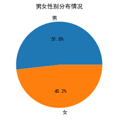

```python
plt.pie(data['性别'].value_counts(),labels=['男','女'],autopct='%1.1f%%')
plt.title('男女性别分布情况')
data['性别'].value_counts()
```

男性稍微多一点，但是区别不大

```
30-34    426
45-49    259
35-39    248
40-44    210
Name: 对应年龄, dtype: int64
```

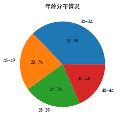

```python
plt.pie(data['对应年龄'].value_counts(),labels=['30-34','45-49','35-39','40-44'],autopct='%1.1f%%')
plt.title('年龄分布情况')
data['对应年龄'].value_counts()
```

30-34年龄段的人群占比最多，占比最少的是40-44

```
16    140
10     85
29     77
27     60
15     51
Name: 兴趣类别1, dtype: int64
```

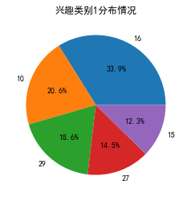

```python
labels = data['兴趣类别1'].value_counts().index
plt.pie(data['兴趣类别1'].value_counts()[:5],labels=labels[:5],autopct='%1.1f%%')
plt.title('兴趣类别1分布情况')
data['兴趣类别1'].value_counts()[:5]
```

```
32    53
21    50
31    49
22    44
30    43
Name: 兴趣类别2, dtype: int64
```

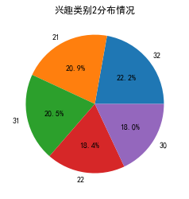

```python
labels = data['兴趣类别2'].value_counts().index
plt.pie(data['兴趣类别2'].value_counts()[:5],labels=labels[:5],autopct='%1.1f%%')
plt.title('兴趣类别2分布情况')
data['兴趣类别2'].value_counts()[:5]
```

```
22    51
32    50
21    45
30    45
20    44
Name: 兴趣类别3, dtype: int64
```

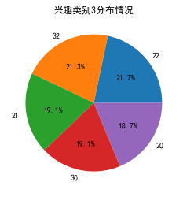

```python
labels = data['兴趣类别3'].value_counts().index
plt.pie(data['兴趣类别3'].value_counts()[:5],labels=labels[:5],autopct='%1.1f%%')
plt.title('兴趣类别3分布情况')
data['兴趣类别3'].value_counts()[:5]
```

```python
print('三个活动对应的点击次数')
print((data.groupby(['活动ID']))['广告点击次数'].sum().sort_values(ascending=False))
print('-------------------------')

print('三个活动的花费金额')
print((data.groupby(['活动ID']))['花费金额'].sum().sort_values(ascending=False))
print('--------------------------')


print('三个活动对应的咨询人数')
print((data.groupby(['活动ID']))['看到广告后询问产品的人数'].sum().sort_values(ascending=False))
print('---------------------------')

print('三个活动对应的购买数量')
print((data.groupby(['活动ID']))['看到广告后购买产品的人数'].sum().sort_values(ascending=False))
```

```
三个活动对应的点击次数
活动ID
1178.0    35210
936.0      2835
916.0       120
Name: 广告点击次数, dtype: int64
-------------------------
三个活动的花费金额
活动ID
1178.0    54374.599956
936.0      4169.350002
916.0       161.280001
Name: 花费金额, dtype: float64
--------------------------
三个活动对应的咨询人数
活动ID
1178.0    2578
936.0      627
916.0       59
Name: 看到广告后询问产品的人数, dtype: int64
---------------------------
三个活动对应的购买数量
活动ID
1178.0    842
936.0     213
916.0      24
Name: 看到广告后购买产品的人数, dtype: int64
```

下面计算CPC、CPA和CPS

单位成本分析

```python
#1178
print('cpc_1178: ',round(54374.599956/35210,3))
print('cpa_1178: ',round(54374.599956/2578,3))
print('cps_1178: ',round(54374.599956/842,3))
print('---------------------------')

#936
print('cpc_936: ',round(4169.350002/2835,3))
print('cpa_936: ',round(4169.350002/627,3))
print('cps_936: ',round(4169.350002/213,3))
print('---------------------------')

#916
print('cpc_916: ',round(161.280001/120,3))
print('cpa_916: ',round(161.280001/59,3))
print('cps_916: ',round(161.280001/24,3))
```

```
cpc_1178:  1.544
cpa_1178:  21.092
cps_1178:  64.578
---------------------------
cpc_936:  1.471
cpa_936:  6.65
cps_936:  19.574
---------------------------
cpc_916:  1.344
cpa_916:  2.734
cps_916:  6.72
```

从上面的计算结果可以看出，这三个广告的CPC值差异不大，但是CPA和CPS的差异是很大的，可以看出916广告的成本更低，如果三个广告的效果一样，那么916广告的投入成本最低，所以如果对916广告加大投入，那么应该可以带来更好的效果

```python
data_1178 = data.query('活动ID == "1178"')
data_936 = data.query('活动ID == "936"')
data_916 = data.query('活动ID == "916"')
```

性别分析

```python
print((data_1178.groupby(['性别']))['看到广告后询问产品的人数'].sum())
print((data_1178.groupby(['性别']))['看到广告后购买产品的人数'].sum())
print('---------------------------')

print((data_936.groupby(['性别']))['看到广告后询问产品的人数'].sum())
print((data_936.groupby(['性别']))['看到广告后购买产品的人数'].sum())
print('---------------------------')

print((data_916.groupby(['性别']))['看到广告后询问产品的人数'].sum())
print((data_916.groupby(['性别']))['看到广告后购买产品的人数'].sum())
```

```
性别
F    1258
M    1320
Name: 看到广告后询问产品的人数, dtype: int64
性别
F    371
M    471
Name: 看到广告后购买产品的人数, dtype: int64
---------------------------
性别
F    365
M    262
Name: 看到广告后询问产品的人数, dtype: int64
性别
F    116
M     97
Name: 看到广告后购买产品的人数, dtype: int64
---------------------------
性别
F    21
M    38
Name: 看到广告后询问产品的人数, dtype: int64
性别
F     8
M    16
Name: 看到广告后购买产品的人数, dtype: int64
```

计算不同活动中男女对应的购买转化率

```python
print("1178数据对应的转化率")
print(data_1178.groupby(['性别'])['看到广告后购买产品的人数'].sum()/data_1178.groupby(['性别'])['看到广告后询问产品的人数'].sum())
print('---------------------------')

print("936数据对应的转化率")
print(data_936.groupby(['性别'])['看到广告后购买产品的人数'].sum()/data_936.groupby(['性别'])['看到广告后询问产品的人数'].sum())
print('---------------------------')

print("916数据对应的转化率")
print(data_916.groupby(['性别'])['看到广告后购买产品的人数'].sum()/data_916.groupby(['性别'])['看到广告后询问产品的人数'].sum())
print('---------------------------')
```

```
1178数据对应的转化率
性别
F    0.294913
M    0.356818
dtype: float64
---------------------------
936数据对应的转化率
性别
F    0.317808
M    0.370229
dtype: float64
---------------------------
916数据对应的转化率
性别
F    0.380952
M    0.421053
dtype: float64
---------------------------
```

从性别这个维度可以看出，三个广告对应的转化率都是男性更高，但是女性同样有不错的购买能力，所以在广告投放的时候对于性别的考虑应该是，更重视男性用户，但同时也不能忽略女性用户

年龄分布分析

```python
print((data_1178.groupby(['对应年龄']))['看到广告后询问产品的人数'].sum())
print((data_1178.groupby(['对应年龄']))['看到广告后购买产品的人数'].sum())
print('---------------------------')

print((data_936.groupby(['对应年龄']))['看到广告后询问产品的人数'].sum())
print((data_936.groupby(['对应年龄']))['看到广告后购买产品的人数'].sum())
print('---------------------------')

print((data_916.groupby(['对应年龄']))['看到广告后询问产品的人数'].sum())
print((data_916.groupby(['对应年龄']))['看到广告后购买产品的人数'].sum())
```

```
对应年龄
30-34    1149
35-39     501
40-44     423
45-49     505
Name: 看到广告后询问产品的人数, dtype: int64
对应年龄
30-34    386
35-39    162
40-44    137
45-49    157
Name: 看到广告后购买产品的人数, dtype: int64
---------------------------
对应年龄
30-34    250
35-39    112
40-44     93
45-49    172
Name: 看到广告后询问产品的人数, dtype: int64
对应年龄
30-34    97
35-39    39
40-44    29
45-49    48
Name: 看到广告后购买产品的人数, dtype: int64
---------------------------
对应年龄
30-34    32
35-39    13
40-44     7
45-49     7
Name: 看到广告后询问产品的人数, dtype: int64
对应年龄
30-34    11
35-39     6
40-44     4
45-49     3
Name: 看到广告后购买产品的人数, dtype: int64
```

```python
print("1178数据对应的转化率")
print(data_1178.groupby(['对应年龄'])['看到广告后购买产品的人数'].sum()/data_1178.groupby(['对应年龄'])['看到广告后询问产品的人数'].sum())
print('---------------------------')

print("936数据对应的转化率")
print(data_936.groupby(['对应年龄'])['看到广告后购买产品的人数'].sum()/data_936.groupby(['对应年龄'])['看到广告后询问产品的人数'].sum())
print('---------------------------')

print("916数据对应的转化率")
print(data_916.groupby(['对应年龄'])['看到广告后购买产品的人数'].sum()/data_916.groupby(['对应年龄'])['看到广告后询问产品的人数'].sum())
```

```
1178数据对应的转化率
对应年龄
30-34    0.335944
35-39    0.323353
40-44    0.323877
45-49    0.310891
dtype: float64
---------------------------
936数据对应的转化率
对应年龄
30-34    0.388000
35-39    0.348214
40-44    0.311828
45-49    0.279070
dtype: float64
---------------------------
916数据对应的转化率
对应年龄
30-34    0.343750
35-39    0.461538
40-44    0.571429
45-49    0.428571
dtype: float64
```

下面对三个广告在不同年龄段的表现进行分析

### 1178：

- 转化率最高的是30-34这个年龄段的人群，但是其他年龄段的转化率也不低，各年龄段之间的差异并不大，在广告投放时不需要过多考虑年龄层面的问题，要进行全面投放

### 936：

- 转化率最高的是30-34这个年龄段，其次是35-39，而且差异比较明显，所以在进行广告投放的时候，应该更多的考虑30-39岁之间的这个用户群体，可以让广告的效果更好

### 916：

- 转化率最高的是40-44这个年龄段的客户，其次是35-39和45-49，可以看出这个产品的定位更倾向于中年客户，所以在广告投放的时候应该更多的考虑35-49之间的这个用户群体，可以让广告的效果更好

下面我会进一步分析，在不同年龄段中男女之间的差异

```python
print((data_1178.groupby(['对应年龄','性别']))['看到广告后询问产品的人数'].sum())
print((data_1178.groupby(['对应年龄','性别']))['看到广告后购买产品的人数'].sum())
print('---------------------------')

print((data_936.groupby(['对应年龄','性别']))['看到广告后询问产品的人数'].sum())
print((data_936.groupby(['对应年龄','性别']))['看到广告后购买产品的人数'].sum())
print('---------------------------')

print((data_916.groupby(['对应年龄','性别']))['看到广告后询问产品的人数'].sum())
print((data_916.groupby(['对应年龄','性别']))['看到广告后购买产品的人数'].sum())
```

```
对应年龄   性别
30-34  F     474
       M     675
35-39  F     232
       M     269
40-44  F     260
       M     163
45-49  F     292
       M     213
Name: 看到广告后询问产品的人数, dtype: int64
对应年龄   性别
30-34  F     143
       M     243
35-39  F      68
       M      94
40-44  F      77
       M      60
45-49  F      83
       M      74
Name: 看到广告后购买产品的人数, dtype: int64
---------------------------
对应年龄   性别
30-34  F     133
       M     117
35-39  F      69
       M      43
40-44  F      60
       M      33
45-49  F     103
       M      69
Name: 看到广告后询问产品的人数, dtype: int64
对应年龄   性别
30-34  F     48
       M     49
35-39  F     26
       M     13
40-44  F     15
       M     14
45-49  F     27
       M     21
Name: 看到广告后购买产品的人数, dtype: int64
---------------------------
对应年龄   性别
30-34  F     12
       M     20
35-39  F      3
       M     10
40-44  F      2
       M      5
45-49  F      4
       M      3
Name: 看到广告后询问产品的人数, dtype: int64
对应年龄   性别
30-34  F     4
       M     7
35-39  F     1
       M     5
40-44  F     1
       M     3
45-49  F     2
       M     1
Name: 看到广告后购买产品的人数, dtype: int64
```

### 1178总结：

- 在30-34岁这个年龄段中，男性的关注度要比女性高出42%，所以应该更关注男性用户
- 在35-39岁这个年龄段中，男性的关注度更高，比女性高出16%，但与女性差异比较小，所以应该全面考虑男女进行广告投放
- 在40-44岁这个年龄段中，女性的关注度更高，且高出男性60%，所以应该更关注女性用户
- 在45-49岁这个年龄段中，女性的关注度更高，且高出男性37%，所以应该更关注女性用户

### 936总结：

- 在30-34岁这个年龄段中，女性的关注度要比男性高出14%，所以应该更关注女性用户
- 在35-39岁这个年龄段中，女性的关注度更高，比男性高出60%，所以应该更关注女性用户
- 在40-44岁这个年龄段中，女性的关注度更高，且高出男性81%，所以应该更关注女性用户
- 在45-49岁这个年龄段中，女性的关注度更高，且高出男性49%，所以应该更关注女性用户
- 所以，可以看出在这个广告中，女性的关注度普遍都高于男性

### 916总结：

- 这个广告中，男性的关注度更高些

下面计算对应的购买转化率

```python
print("1178数据对应的转化率")
print(data_1178.groupby(['对应年龄','性别'])['看到广告后购买产品的人数'].sum()/data_1178.groupby(['对应年龄','性别'])['看到广告后询问产品的人数'].sum())
print('---------------------------')

print("936数据对应的转化率")
print(data_936.groupby(['对应年龄','性别'])['看到广告后购买产品的人数'].sum()/data_936.groupby(['对应年龄','性别'])['看到广告后询问产品的人数'].sum())
print('---------------------------')

print("916数据对应的转化率")
print(data_916.groupby(['对应年龄','性别'])['看到广告后购买产品的人数'].sum()/data_916.groupby(['对应年龄','性别'])['看到广告后询问产品的人数'].sum())
```

```
1178数据对应的转化率
对应年龄   性别
30-34  F     0.301688
       M     0.360000
35-39  F     0.293103
       M     0.349442
40-44  F     0.296154
       M     0.368098
45-49  F     0.284247
       M     0.347418
dtype: float64
---------------------------
936数据对应的转化率
对应年龄   性别
30-34  F     0.360902
       M     0.418803
35-39  F     0.376812
       M     0.302326
40-44  F     0.250000
       M     0.424242
45-49  F     0.262136
       M     0.304348
dtype: float64
---------------------------
916数据对应的转化率
对应年龄   性别
30-34  F     0.333333
       M     0.350000
35-39  F     0.333333
       M     0.500000
40-44  F     0.500000
       M     0.600000
45-49  F     0.500000
       M     0.333333
dtype: float64
```

用户会不会购买才是最重要的一步，也是可以体现出产品好坏的最主要的指标之一，下面进行分析

### 1178总结：

- 全年龄段都是男性的购买转化率更高，所以应该更关注男性用户，但因为女性购买转化率也并没有低太多，所以女性也同样需要关注；但是有一点需要关注，就是在40-49岁这个年龄段中，女性的关注度是要比男性高的，但是购买转化率却没有男性高，我觉得这有可能是因为产品的某些因素导致女性不愿意购买，所以最好针对这类人群进行更详细的分析，然后完善产品属性。

### 936总结：

- 与1178有类似的问题，除了35-39岁这个年龄段的购买转化率是女性更高，与关注度统一，其他的年龄段都是女性关注度更高，但是购买转化率却低于男性，所以还是需要对产品进行进一步的分析，找出女性不愿意购买的原因

下面是兴趣维度的分析

首先是单一维度

1178兴趣类别1分析

```python
print("1178")
print((data_1178.groupby(['兴趣类别1']))['看到广告后询问产品的人数'].sum().sort_values(ascending=False)[:5])
print((data_1178.groupby(['兴趣类别1']))['看到广告后购买产品的人数'].sum().sort_values(ascending=False)[:5])
print((data_1178.groupby(['兴趣类别1'])['看到广告后购买产品的人数'].sum()/data_1178.groupby(['兴趣类别1'])['看到广告后询问产品的人数'].sum()).sort_values(ascending=False)[:20])
```

```
1178
兴趣类别1
16    273
29    253
10    212
27    199
15    155
Name: 看到广告后询问产品的人数, dtype: int64
兴趣类别1
29    110
16    100
10     67
15     48
27     42
Name: 看到广告后购买产品的人数, dtype: int64
```

[output cut: 22 more lines]

兴趣类别2分析

```python
print("1178")
print((data_1178.groupby(['兴趣类别2']))['看到广告后询问产品的人数'].sum().sort_values(ascending=False)[:5])
print((data_1178.groupby(['兴趣类别2']))['看到广告后购买产品的人数'].sum().sort_values(ascending=False)[:5])
print((data_1178.groupby(['兴趣类别2'])['看到广告后购买产品的人数'].sum()/data_1178.groupby(['兴趣类别2'])['看到广告后询问产品的人数'].sum()).sort_values(ascending=False)[:20])
```

```
1178
兴趣类别2
20    216
28    105
32    103
34    100
21     93
Name: 看到广告后询问产品的人数, dtype: int64
兴趣类别2
20    84
34    44
32    40
35    36
28    31
Name: 看到广告后购买产品的人数, dtype: int64
```

[output cut: 22 more lines]

1178兴趣类别3分析

```python
print("1178")
print((data_1178.groupby(['兴趣类别3']))['看到广告后询问产品的人数'].sum().sort_values(ascending=False)[:5])
print((data_1178.groupby(['兴趣类别3']))['看到广告后购买产品的人数'].sum().sort_values(ascending=False)[:5])
print((data_1178.groupby(['兴趣类别3'])['看到广告后购买产品的人数'].sum()/data_1178.groupby(['兴趣类别3'])['看到广告后询问产品的人数'].sum()).sort_values(ascending=False)[:20])
```

```
1178
兴趣类别3
31    127
33    124
30    123
29    113
34    111
Name: 看到广告后询问产品的人数, dtype: int64
兴趣类别3
34    48
31    41
30    39
21    38
33    37
Name: 看到广告后购买产品的人数, dtype: int64
```

[output cut: 22 more lines]

可以看出，在1178这个广告中，询问和购买最多的数量都是基本一致的，但是购买转化率却并不是很理想，所以应该调查这部分人群，找出不愿意购买的原因是什么

936广告兴趣类别1分析

```python
print("936")
print((data_936.groupby(['兴趣类别1']))['看到广告后询问产品的人数'].sum().sort_values(ascending=False)[:5])
print((data_936.groupby(['兴趣类别1']))['看到广告后购买产品的人数'].sum().sort_values(ascending=False)[:5])
print((data_936.groupby(['兴趣类别1'])['看到广告后购买产品的人数'].sum()/data_936.groupby(['兴趣类别1'])['看到广告后询问产品的人数'].sum()).sort_values(ascending=False)[:5])
```

```
936
兴趣类别1
16    120
10     55
29     50
27     38
26     31
Name: 看到广告后询问产品的人数, dtype: int64
兴趣类别1
16    33
10    22
29    19
15    11
27    11
Name: 看到广告后购买产品的人数, dtype: int64
兴趣类别1
105    1.0
104    1.0
102    1.0
101    1.0
65     0.8
dtype: float64
```

兴趣类别2分析

```python
print("936")
print((data_936.groupby(['兴趣类别2']))['看到广告后询问产品的人数'].sum().sort_values(ascending=False)[:5])
print((data_936.groupby(['兴趣类别2']))['看到广告后购买产品的人数'].sum().sort_values(ascending=False)[:5])
print((data_936.groupby(['兴趣类别2'])['看到广告后购买产品的人数'].sum()/data_936.groupby(['兴趣类别2'])['看到广告后询问产品的人数'].sum()).sort_values(ascending=False)[:5])
```

```
936
兴趣类别2
32    41
22    38
17    33
21    31
18    28
Name: 看到广告后询问产品的人数, dtype: int64
兴趣类别2
29    12
33    12
22    12
20    11
21    11
Name: 看到广告后购买产品的人数, dtype: int64
兴趣类别2
7      1.00
109    1.00
108    1.00
104    1.00
69     0.75
dtype: float64
```

兴趣类别3分析

```python
print("936")
print((data_936.groupby(['兴趣类别3']))['看到广告后询问产品的人数'].sum().sort_values(ascending=False)[:5])
print((data_936.groupby(['兴趣类别3']))['看到广告后购买产品的人数'].sum().sort_values(ascending=False)[:5])
print((data_936.groupby(['兴趣类别3'])['看到广告后购买产品的人数'].sum()/data_936.groupby(['兴趣类别3'])['看到广告后询问产品的人数'].sum()).sort_values(ascending=False)[:5])
```

```
936
兴趣类别3
22    37
20    36
19    34
32    31
17    30
Name: 看到广告后询问产品的人数, dtype: int64
兴趣类别3
22    12
19    10
20    10
34    10
33     9
Name: 看到广告后购买产品的人数, dtype: int64
兴趣类别3
108    1.0
106    1.0
103    1.0
71     1.0
7      0.8
dtype: float64
```

可以看出，在936这个广告中，询问和购买最多的数量都是基本一致的，但是购买转化率却并不是很理想，所以应该调查这部分人群，找出不愿意购买的原因是什么

```python
print("916")
print((data_916.groupby(['兴趣类别3']))['看到广告后询问产品的人数'].sum().sort_values(ascending=False)[:5])
print((data_916.groupby(['兴趣类别3']))['看到广告后购买产品的人数'].sum().sort_values(ascending=False)[:5])
print((data_916.groupby(['兴趣类别3'])['看到广告后购买产品的人数'].sum()/data_916.groupby(['兴趣类别3'])['看到广告后询问产品的人数'].sum()).sort_values(ascending=False)[:5])
```

```
916
兴趣类别3
20    10
22     6
17     6
32     5
31     4
Name: 看到广告后询问产品的人数, dtype: int64
兴趣类别3
20    6
32    3
11    2
18    2
24    1
Name: 看到广告后购买产品的人数, dtype: int64
兴趣类别3
24    1.0
30    1.0
11    1.0
18    1.0
29    1.0
dtype: float64
```

916兴趣类别2分析

```python
print("916")
print((data_916.groupby(['兴趣类别2']))['看到广告后询问产品的人数'].sum().sort_values(ascending=False)[:5])
print((data_916.groupby(['兴趣类别2']))['看到广告后购买产品的人数'].sum().sort_values(ascending=False)[:5])
print((data_916.groupby(['兴趣类别2'])['看到广告后购买产品的人数'].sum()/data_916.groupby(['兴趣类别2'])['看到广告后询问产品的人数'].sum()).sort_values(ascending=False)[:5])
```

```
916
兴趣类别2
19    10
18     4
26     4
20     4
33     4
Name: 看到广告后询问产品的人数, dtype: int64
兴趣类别2
33    3
18    3
21    3
19    2
30    2
Name: 看到广告后购买产品的人数, dtype: int64
兴趣类别2
13    1.00
30    1.00
21    1.00
33    0.75
18    0.75
dtype: float64
```

916兴趣类别3

```python
print("916")
print((data_916.groupby(['兴趣类别3']))['看到广告后询问产品的人数'].sum().sort_values(ascending=False)[:5])
print((data_916.groupby(['兴趣类别3']))['看到广告后购买产品的人数'].sum().sort_values(ascending=False)[:5])
print((data_916.groupby(['兴趣类别3'])['看到广告后购买产品的人数'].sum()/data_916.groupby(['兴趣类别3'])['看到广告后询问产品的人数'].sum()).sort_values(ascending=False)[:5])
```

```
916
兴趣类别3
20    10
22     6
17     6
32     5
31     4
Name: 看到广告后询问产品的人数, dtype: int64
兴趣类别3
20    6
32    3
11    2
18    2
24    1
Name: 看到广告后购买产品的人数, dtype: int64
兴趣类别3
24    1.0
30    1.0
11    1.0
18    1.0
29    1.0
dtype: float64
```

可以看出，在916这个广告中，询问和购买最多的数量都是基本一致的，但是购买转化率却并不是很理想，所以应该调查这部分人群，找出不愿意购买的原因是什么

还可以使用兴趣类别的各种组合来找出需要修改的地方